# Hypothesis: How does FOMC determine Interest Rate?

November 13, 2016

## Motivation

- Federal Open Market Committee (FOMC) alway make the desicion beyond the market expectation, which cause huge global capital market volatility
- Find out the impact factor that influence FOMC dicision
- Set up one model to avoid the risk of market volatility
- Generte profit during the market volatility

## Perspective

- Lineaer Regression (numeric) -Find out the equation to predict the precise interest rate
- Classfication (Multinomial) -Find out the possibility of interest rate change

## Linear Regression Model

\(Interest.Rate =\) \(13.09 + 1.1*BankLoan\) \(+ 0.39RealExport\) \(+ 0.148*US.Dollar.Index\) \(+ 0.93*Personal.Consumption.Expenditures\) \(- 1.03*UnEm.rate\) \(- 0.13631*RGDP\) \(- 1.08996*Total.Vehicle.Sales\)

```
##
## Call:
## lm(formula = Interest.Rate ~ . - Date, data = Ist.complete_final)
##
## Residuals:
##     Min      1Q  Median      3Q     Max
## -7.7459 -0.9721 -0.1388  0.9188  5.8663
##
## Coefficients:
##                                   Estimate Std. Error t value Pr(>|t|)
## (Intercept)                       13.09168    2.50591   5.224 5.56e-07 ***
## unem.rate                         -1.03612    0.14782  -7.009 6.91e-11 ***
## BankLoan                           1.10072    0.17018   6.468 1.23e-09 ***
## RealExport                         0.38990    0.07774   5.015 1.43e-06 ***
## Personal.Consumption.Expenditures  0.93013    0.31108   2.990  0.00325 **
## RGDP                              -0.13631    0.06203  -2.197  0.02948 *
## Total.Vehicle.Sales               -1.08996    0.10183 -10.704  < 2e-16 ***
## U.S.Dollar.Index                   0.14807    0.01052  14.077  < 2e-16 ***
## ---
## Signif. codes:  0 '***' 0.001 '**' 0.01 '*' 0.05 '.' 0.1 ' ' 1
##
## Residual standard error: 1.815 on 155 degrees of freedom
## Multiple R-squared:  0.7074, Adjusted R-squared:  0.6942
## F-statistic: 53.53 on 7 and 155 DF,  p-value: < 2.2e-16
```

## Linear Regression Model—Feature Selection

- Mannully Select :remove the variables increasing as time going on or convert to percentage change

[figure not shown]

## Feature Selection

- Remove the varibles that caused by Interest rate such as LIBOR.Lodon,ten.yr.T.Rate,one.yr.Treasury.Rate,Bond.Yield, T.bill.MRate
- Remove the variables that with high multicollinearity such as Unemployment.Level,Em_Pop.rate,Light.vehicle.sale, Employee.payroll,LFP.rate,NewHouse.permit,Inflation
- Remove the annually variables and no correlation such as Inflation,GDP_CHN,Stock.Capitalization.to.GDP,M2.velocity, Industrial.Index,ConsumerPrice,NetExport,Debt.rates
- Final filter by AIC: Disposable.income,Psaving.rate, New.House.Start,M1.velocity,PrivateInvest

## Linear model result–VIF

```
##                         unem.rate                          BankLoan
##                          2.594838                          1.106390
##                        RealExport Personal.Consumption.Expenditures
##                          1.565897                          1.368003
##                              RGDP               Total.Vehicle.Sales
##                          1.845306                          2.735199
##                  U.S.Dollar.Index
##                          1.183198
```

## Linear model result–avPlots

[figure not shown]

## Linear model result–influencePlot

[figure not shown]

```
##       StudRes       Hat     CookD
## 622  2.002059 0.2186111 0.1375056
## 706 -5.106286 0.1887666 0.6527997
```

## Linear model result

[figure not shown]

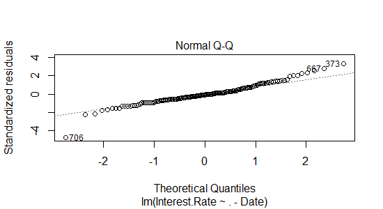

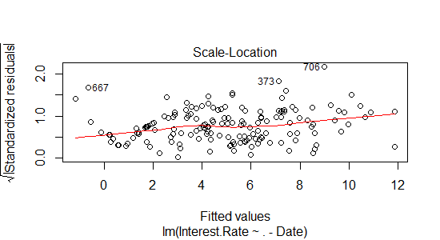

## Abnormal sample investigation

### On March 10, 2000 the NASDAQ peaked at 5,132.52 intraday before closing at 5,048.62. Afterwards, the NASDAQ fell as much as 78%

### starting from November 2008, several countries launched large 'help packages' for their economies.

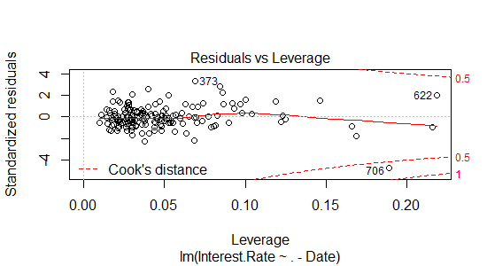

```
##           Date Prediction Real
## 622 2001-10-01  -1.161944 2.02
## 706 2008-10-01   8.995944 2.02
```

## Predict interest rate for 2016 fall

```
##                   interest.real
## interest.predict   1
##   2.6048004484272  1
##   2.88362988546305 1
##   3.34516568828527 1
```

[figure not shown]

## Multi-class Classfication—Neural Network

```
## [1] "unem.rate"                         "BankLoan"
## [3] "RealExport"                        "Personal.Consumption.Expenditures"
## [5] "RGDP"                              "Total.Vehicle.Sales"
## [7] "U.S.Dollar.Index"                  "IR"
```

```
##        -1         0         1
## 0.1122497 0.5689175 0.3188327
```

## Binary Classfication–Tree

```
##
## tree.test.pre   0   1
##             0 133  33
##             1  37  38
```

[output not shown]

```
##     0 1
## 801 1 0
```

## Binary Classfication–Random Tree

```
##
## Call:
##  randomForest(formula = IR ~ ., data = Ist.month.class.bc, importance = TRUE,      subset = train)
##                Type of random forest: classification
##                      Number of trees: 500
## No. of variables tried at each split: 2
##
##         OOB estimate of  error rate: 25%
## Confusion matrix:
##     0  1 class.error
## 0 356 48   0.1188119
## 1  92 64   0.5897436
```

## Multi-class Classfication–Random Tree

```
##
## Call:
##  randomForest(formula = IR ~ ., data = Ist.month.class.mc, importance = TRUE,      subset = train.mc)
##                Type of random forest: classification
##                      Number of trees: 500
## No. of variables tried at each split: 2
##
##         OOB estimate of  error rate: 26.25%
## Confusion matrix:
##    -1   0  1 class.error
## -1 21  54  1   0.7236842
## 0  17 362 25   0.1039604
## 1   1  49 30   0.6250000
```

```
##     -1     0     1
## 801  0 0.988 0.012
## attr(,"class")
## [1] "matrix" "votes"
```

### Future: use Anomaly Detection Algorithm to do the binary classification